# Hi-C processing 101

Author

Jacques SERIZAY

Published

January 25, 2023

**Aim:** This workshop aims at learning from scratch how to process, check, visualize and integrate Hi-C data with other datasets.

More specifically, this will teach you:

- Set up a `conda` environment and install the required packages with `micromamba`
- Align fastq files to a genome reference and generate a `.pairs` file with `hicstuff`
- Understand the sanity checks performed by `hicstuff`
- Bin filtered pairs into a contact matrix (`.cool`) using `cooler`
- Generate a balanced, multi-resolution contact matrix file (`.mcool`) with `cooler`
- Identify features (e.g. loops) using `chromosight`
- Use R to perform advanced operations on contact matrices:
  - Import and subset contact matrices (`.cool`, `.hic`, `HiC-Pro` derived…)
  - Import and subset pairs files
  - Arithmetics: merge, divide, smoothen, balance, autocorrelate, …
  - Analysis: P(s), virtual 4C, scalograms, cis/trans interactions
  - Mapping: chromatin loops (via `chromosight`), topological domains, compartments
  - Visualizing: contact maps, features, aggregated maps, saddle plots
- Integrate other genome-wide modalities (RNA-seq, ChIP-seq, …)

## 1 Get sequencing reads data from `Rsg_reads`

First, you need to set up few environment variables. Let’s start with the user: who are you? Start by creating a `USER` variable saving your Pasteur ID.

```
bash
```

```bash
USER=<...> ## e.g. USER=jaseriza
```

We will use library reads from:

**Libraries**

- `CH112` Hi-C library in a WT S288C background
- `CH224` (input: `CH225`) Scc1 ChIP-seq library in a WT S288C background
- `SRR2045244` RNA-seq library

```
bash
```

```bash
# -------- Prepare project directoy
mkdir ~/formation_HiC    ## `mkdir` = create a folder
cd ~/formation_HiC       ## `cd` = Change Directory
mkdir data/              ## `mkdir` = create a folder

# -------- Download fastq files from Rsg_reads (on sftpcampus)
## `rsync` = Copy a file over `ssh` (equivalent of local `cp`)
rsync --progress "${USER}"@sftpcampus.pasteur.fr:/pasteur/gaia/projets/p02/Rsg_reads/3_YEAST/collab_Beckouet_cohesin/CH112* data/
rsync --progress "${USER}"@sftpcampus.pasteur.fr:/pasteur/gaia/projets/p02/Rsg_reads/3_YEAST/Mycoplasma/CH224* data/
rsync --progress "${USER}"@sftpcampus.pasteur.fr:/pasteur/gaia/projets/p02/Rsg_reads/3_YEAST/Mycoplasma/CH225* data/

# -------- Download fastq files from SRA (online)
## `wget` = Download a file from internet
wget ftp://ftp.sra.ebi.ac.uk/vol1/fastq/SRR204/004/SRR2045244/SRR2045244_1.fastq.gz -O data/SRR2045244_R1.fastq.gz
wget ftp://ftp.sra.ebi.ac.uk/vol1/fastq/SRR204/004/SRR2045244/SRR2045244_2.fastq.gz -O data/SRR2045244_R2.fastq.gz

# -------- Check data/ folder
## `ls` = List files in a directory
ls .
ls data/
ls -l data/
ls -ltFh data/
```

Let’s have a look at the content of a compressed fastq file

```
bash
```

```bash
## `zcat` = Uncompress and file and output its content in the terminal window
## `|` = Pass the output of a command as the input of the next command
zcat data/CH112_S4_R1_001.gz | head     ## `head` = Check the first 10 lines of a text file
zcat data/CH112_S4_R2_001.gz | wc -l    ## `wc -l` = Count the number of lints in a text file
```

## 2 Create a `micromamba` environment and install required softwares for Hi-C

Check the `README.md` on the [Github repository](https://github.com/js2264/training_HiC) to see how to set up a `micromamba` environment.

## 3 Process Hi-C data with hicstuff

### 3.1 Preparing for `hicstuff`

Let’s see what `hicstuff` documentation says:

```
bash
```

```bash
hicstuff --help
hicstuff pipeline --help
```

If we want to run the entire hicstuff pipeline, we will need at least:

**Arguments**

- `--genome`=FILE
- `<input1>`
- `<input2>`

We have the data (`input1` and `input2`) as fastq files (check `data/` folder…), but we also need a `genome` index or in fasta sequence. We can get one from `Rsg/references_genomes/`.

```
bash
```

```bash
## Download genome reference from sftpcampus
mkdir -p genomes/S288c/
rsync --progress "${USER}"@sftpcampus.pasteur.fr:/pasteur/gaia/entites/Rsg/reference_genomes/yeast/Saccharomyces_cerevisiae/S288C/S288c.fa genomes/S288c/
rsync --progress "${USER}"@sftpcampus.pasteur.fr:/pasteur/gaia/entites/Rsg/reference_genomes/yeast/Saccharomyces_cerevisiae/S288C/S288c.gtf genomes/S288c/
ls -l genomes/S288c/
bowtie2-build genomes/S288c/S288c.fa genomes/S288c/S288c
ls -l genomes/S288c/
```

### 3.2 Running `hicstuff`

The generic command for hicstuff pipeline is something like:

```bash
## GENERIC COMMAND: TO COMPLETE
## DO NOT RUN THIS!
hicstuff pipeline \
   <some-options> \
   --genome genomes/S288c/S288c.fa \ # Genome info
   data/CH112_S4_R1_001.gz \ # read R1 info
   data/CH112_S4_R2_001.gz   # read R2 info
```

**Options I find useful**

- `--distance-law` Generates a distance law file and plot
- `--plot` Generates informative QC plots in the output directory at different steps of the pipeline.
- `--filter` Filter out spurious 3C events (loops and uncuts) using hicstuff filter (Cournac et al. BMC Genomics, 2012)
- `--duplicates` Filter out PCR duplicates based on read positions.
- **–binning** **Set a base resolution to generate binned matrix file.**

**Other useful options**

- `--enzyme={STR|INT}` Restriction enzyme or “mnase”
- `--mapping=STR` normal|iterative|cutsite mapping strategy
- `--outdir=DIR` Output directory
- `--prefix=STR` Overrides default filenames and prefixes all output files with a custom name.
- `--threads=INT` Number of threads to allocate.

So, for me, a typical “extended” hicstuff pipeline command may look like this:

```
bash
```

```bash
hicstuff pipeline \
   --threads 12 \
   --enzyme DpnII,HinfI \
   --filter \
   --duplicates \
   --prefix CH112 \
   --binning 1000 \
   --plot \
   --distance-law \
   --outdir results \
   --genome genomes/S288c/S288c.fa \
   data/CH112_S4_R1_001.gz \
   data/CH112_S4_R2_001.gz
```

**Few notes on hicstuff pipeline**

Here are several important notes regarding `hicstuff pipeline`:

- **DO SET A `--binning 1000` (or other resolution). This will automatically bin your matrix at the chosen resolution and at larger resolutions.**
- IMO, `--filter` is what makes `hicstuff` unique compared to other workflows.
- With longer reads, I would typically run hicstuff in `--mapping iterative` mode to map as many reads as possible.
- If you are looking for maximum mappability and pairs number, `--mapping cutsite` will further increase these numbers. It will also exponentially increase computing time and disk storage, be warned.
- `enzyme` can take a bin size to directly bin aligned reads into fixed-width genomic windows, but filtering won’t work. This is generally non-advised.
- I actually prefer to compute the P(s) (distance law) directly in R myself, from the `pairs` file. We’ll see how to do that later. In this case, you can skip `--distance-law`, for larger datasets this step takes a significant amount of time to compute.

### 3.3 Checking the output files

```
bash
```

```bash
tree results
```

**Output files**

```bash
results/
|-- CH112.chr.tsv
|-- CH112.mcool                     ## There are the main output files
|-- CH112.valid_idx_pcrfree.pairs   ## There are the main output files
|-- CH112.distance_law.txt
|-- CH112.frags.tsv
|-- CH112.hicstuff_20230127153908.log
|-- plots/
|...|-- CH112_distance_law.pdf
|...|-- CH112_event_distance.pdf
|...|-- CH112_event_distribution.pdf
|...\`-- CH112_frags_hist.pdf
\`-- tmp/
....|-- CH112.for.bam
....|-- CH112.genome.fa.gz
....|-- CH112.genome.fa.gz.1.bt2
....|-- CH112.genome.fa.gz.2.bt2
....|-- CH112.genome.fa.gz.3.bt2
....|-- CH112.genome.fa.gz.4.bt2
....|-- CH112.genome.fa.gz.rev.1.bt2
....|-- CH112.genome.fa.gz.rev.2.bt2
....|-- CH112.rev.bam
....|-- CH112.valid.pairs
....|-- CH112.valid_idx.pairs
....|-- CH112.valid_idx_filtered.pairs

2 directories, 22 files
```

We can check `hicstuff` log to make sure everything went smoothly:

```
bash
```

```bash
cat results/CH112.hicstuff_20230127153908.log
```

```bash
## hicstuff: v3.2.1 log file
## date: 2023-10-02 23:57:25
## enzyme: DpnII,HinfI
## input1: data/CH112_S4_R1_001.gz
## input2: data/CH112_S4_R2_001.gz
## ref: genomes/S288c/S288c.fa
---
INFO :: The default output format is now `.cool`. The Hi-C matrix will be generated with cooler v0.9.3 (Abdennur & Mirny, Bioinformatics 2020).
INFO :: bowtie2 index not found at results/tmp/testHiC.genome.fa.gz, generating a local temporary index.
INFO :: Checking content of fastq files.
INFO :: 47419366 reads found in each fastq file.
2023-01-27,15:39:17 :: INFO :: bowtie2 index not found at results/tmp/CH112.genome.fa.gz, generating a local temporary index.
2023-01-27,15:45:33 :: INFO :: 77% reads (single ends) mapped with Q >= 30 (36505851/47419366)
2023-01-27,15:49:17 :: INFO :: Filtering with thresholds: uncuts=12 loops=14
2023-01-27,15:50:12 :: INFO :: Proportion of inter contacts: 22.73% (intra: 9703399, inter: 2853784)
2023-01-27,15:50:12 :: INFO :: 3252258 pairs discarded: Loops: 752085, Uncuts: 2489391, Weirds: 10782
2023-01-27,15:50:12 :: INFO :: 12557183 pairs kept (79.43%)
2023-01-27,15:54:28 :: INFO :: 35% PCR duplicates have been filtered out (4466833 / 12557183 pairs)
INFO:cooler.create:Writing chunk 0: results/tmp6082rqc_.multi.cool::0
INFO:cooler.create:Creating cooler at "results/tmp6082rqc_.multi.cool::/0"
INFO:cooler.create:Writing chroms
INFO:cooler.create:Writing bins
INFO:cooler.create:Writing pixels
INFO:cooler.create:Writing indexes
INFO:cooler.create:Writing info
INFO:cooler.create:Merging into results/testHiC.cool
INFO:cooler.create:Creating cooler at "results/testHiC.cool::/"
INFO:cooler.create:Writing chroms
INFO:cooler.create:Writing bins
INFO:cooler.create:Writing pixels
INFO:cooler.reduce:nnzs: [50982]
INFO:cooler.reduce:current: [50982]
INFO:cooler.create:Writing indexes
INFO:cooler.create:Writing info
2023-01-27,15:55:37 :: INFO :: Contact map generated after 0h 16m 29s
```

## 4 Interact with a `.pairs` file

### 4.1 What is a `.pairs` file?

Each `contact` identified in Hi-C can be listed as a pair of 2 genomic locations.  
For each pair of genomic loci making a contact, one comes from the `*_R1` fastq file and the other comes from the `*_R2` fastq file.  
The `.pairs` format summarizes these contacts, and as such, **it is the main, most important output of a Hi-C experiment**. It is a human-readable, simplified version of a bam file generated from a paired-end sequencing. Information regarding sequencing/mapping quality, actual sequence, or other SAM flags, are discarded. The only remaining information are the genomic location of the end of each read.

The `.pairs` format has been formally defined as a tab-delimited text file containing 7 columns at least:

```bash
<read_id> <chrom1> <pos1> <chrom2> <pos2> <strand1> <strand2>
```

| index | name | description |
| --- | --- | --- |
| 1 | read_id | the ID of the read as defined in fastq files |
| 2 | chrom1 | the chromosome of the alignment on side 1 |
| 3 | pos1 | the 1-based genomic position of the outer-most (5’) mapped bp on side 1 |
| 4 | chrom2 | the chromosome of the alignment on side 2 |
| 5 | pos2 | the 1-based genomic position of the outer-most (5’) mapped bp on side 2 |
| 6 | strand1 | the strand of the alignment on side 1 |
| 7 | strand2 | the strand of the alignment on side 2 |

The `pairs` file used to generate the Hi-C `.mcool` matrix is present in the output directory.

```
bash
```

```bash
ls -ltFh results/*.pairs*
```

```bash
-rw-r--r-- 1 rsg rsg 1.2M Oct  2 23:58 results/CH112.valid_idx_pcrfree.pairs.gz
```

Additionally, a number of `.pairs` files are present in `results/tmp/` (if `--no-cleanup` was set):

```
bash
```

```bash
ls -ltFh results/tmp/*.pairs
```

```bash
-rw-rw-r-- 1 rsg rsg 943M 27 janv.  15:50 results/tmp/CH112.valid_idx_filtered.pairs
-rw-rw-r-- 1 rsg rsg 1,2G 27 janv.  15:49 results/tmp/CH112.valid_idx.pairs
-rw-rw-r-- 1 rsg rsg 1,1G 27 janv.  15:45 results/tmp/CH112.valid.pairs
```

How many pairs are listed in each `.pairs` file?

```
bash
```

```bash
wc -l results/tmp/*.pairs
```

```bash
15809461 results/tmp/CH112.valid.pairs
15809461 results/tmp/CH112.valid_idx.pairs
12557203 results/tmp/CH112.valid_idx_filtered.pairs
8090370 results/tmp/CH112.valid_idx_pcrfree.pairs
```

What do these `.pairs` files actually look like?

```
bash
```

```bash
head results/tmp/CH112.valid_idx_pcrfree.pairs -n 30
```

```bash
## pairs format v1.0
#sorted: chr1-pos1-chr2-pos2
#columns: readID chr1 pos1 chr2 pos2 strand1 strand2 frag1 frag2
#chromsize: I 230218
#chromsize: II 813184
#chromsize: III 316620
#chromsize: IV 1531933
#chromsize: V 576874
#chromsize: VI 270161
#chromsize: VII 1090940
#chromsize: VIII 562643
#chromsize: IX 439888
#chromsize: X 745751
#chromsize: XI 666816
#chromsize: XII 1078177
#chromsize: XIII 924431
#chromsize: XIV 784333
#chromsize: XV 1091291
#chromsize: XVI 948066
#chromsize: Mito 85779
NS500150:527:HHGYNBGXF:1:11102:20886:5813       I       35      III     301620  +       +       0       8196
NS500150:527:HHGYNBGXF:1:21112:2714:13921       I       39      V       543888  +       -       0       21278
NS500150:527:HHGYNBGXF:1:12303:14200:17422      I       41      I       68819   +       -       0       385
NS500150:527:HHGYNBGXF:3:22512:8255:11137       I       51      VIII    197898  +       +       0       31149
NS500150:527:HHGYNBGXF:1:22306:8892:6435        I       52      V       523161  +       -       0       21145
NS500150:527:HHGYNBGXF:1:22303:12518:17386      I       53      I       21088   +       +       0       80
NS500150:527:HHGYNBGXF:4:12502:8300:8871        I       55      I       44355   -       -       0       204
NS500150:527:HHGYNBGXF:2:12308:7097:9339        I       64      VII     401224  +       -       0       25718
NS500150:527:HHGYNBGXF:3:13409:17355:18015      I       65      XIV     515520  +       -       0       60510
NS500150:527:HHGYNBGXF:3:22610:19850:5032       I       66      I       10809   +       -       0       40
```

**Few notes on which `.pairs` file to use**

- The `*_pcrfree.pairs` file is the latest file generated (after filtering) if you have specified `--duplicates`.
- If you have a good reason to think that you may use pairs including PCR duplicates, go for the `*_filtered.pairs` file.
- If you have a good reason to think that you may use unfiltered pairs (including looping DNA fragments or uncut DNA fragments), go for the `*.valid_idx.pairs` file.
- The remaining `*.valid.pairs` is redundant with the `*.valid_idx.pairs` and is probably not useful, it can and should be deleted.

A good practice is also to remove `.bam` files kept in the `tmp/` folder.

### 4.2 Check the QC plots for sanity controls

Several QC plots are generated by `hicstuff`, to assess the quality of pairs identified by HiC.

> Understanding the `event_distance` plot

[figure not shown]

This plot illustrates how the nature of read pairs is inferred, based on the distance between the two reads (shown on the X axis) and their orientation. A pair of reads can have 4 different orientations: `--`, `++`, `-+` and `+-` (each `+` or `-` referring to the alignment on positive strand on negative strand of the DNA, i.e. directly on the genome reference or on its reverse complement).

- `--` and `++` pairs necessarily come from real religation events between two distant genomic loci (as long as there is at least > 0 restriction site between the two pairs). These pairs are **unambiguously informative**.
- If there is no restriction site between reads of a `--`/`++` pair, this pair is annotated as “weird”, as it should not exist.
- `+-` and `-+` pairs are **ambiguous**: they could either come from real religation events between two distant genomic loci (**informative** pairs) or from circular self-religated fragments (“loops”) or undigested fragments (“uncuts”). `hicstuff` **filters** these ambiguous pairs by finding an appropriate threshold in minimum number of restriction fragments. `+-` and `-+` pairs with less restriction fragments between their extremities are considered “uncut” fragments and “self-religated” (“loops”) fragments and are discarded. The rest of the `+-` and `-+` pairs are kept.

`hicstuff` generates a plot showing the distribution of these possible events:

- `--` and `++` informative pairs (in green)
- `--` and `++` weird pairs (with 0 restriction site between their extremities, in gray/dark)
- `-+` pairs: before the “loops” threshold, these pairs are annotated as “loops”; past this threshold, these pairs are considered informative.
- `+-` pairs: before the “uncut” threshold, these pairs are annotated as “uncut”; past this threshold, these pairs are considered informative.

**How hicstuff calculates the thresholds to estimate “loops” and “uncuts”**

Filtering consists in excluding `+-` and `-+` pairs if their reads are closer than a threshold in minimum number of restriction fragments. This threshold represents **the distance at which the abundance of these events stop deviating significantly from the rest of the library**. It is estimated using the median absolute deviation of pairs.

More info [here](https://hicstuff.readthedocs.io/en/latest/api/hicstuff.html#module-hicstuff.filter)

> Understanding the `event_distribution` plot

[figure not shown]

This pie chart represents the overall distribution of pairs for a Hi-C sample, as annotated by hicstuff.

- Anything in purple (3D inter) or neon green (3D intra) comes is from **informative**, selected pairs. This is the value you want to be the highest! IME anything >50% is good. Lower than 20%, you’d have to question the quality of your biotin enrichment…
- “Weirds” should be << 1%.
- Loops and uncut will vary, according to their infered thresholds (explained in the previous subsection). The thresholds used to infer loops (uncut) fragments from `-+` (`+-`) pairs are also printed in this plot.

## 5 Creating a `.cool` contact matrix

**IMPORTANT**

If you have specified a `--binning` base resolution, `hicstuff pipeline` will generate and bin the contact matrix at the desired resolution.  
In this case, the following section can be read to understand what is performed, but there is no need to perform any of these operations as they are taken care of by `hicstuff pipeline`.

### 5.1 What is a `.cool` file?

A `.pairs` is the most important file generated in a Hi-C pipeline, but it’s not the easiest one to use: it is huge, uncompressed, and unsummarized. In order to simplify the representation of Hi-C, pairs can be binned using a fixed-sized window (e.g. 1000 bp): every pair end falling in a 1kb bin will be assigned to this bin (same for the other end).

Eventually, one could transform this set of three (unambiguous informative) pairs:

```
CH112.valid_idx_pcrfree.pairs
```

```bash
<read_id> <chrom1> <pos1> <chrom2> <pos2> <strand1> <strand2>
NS500150:527:HHGYNBGXF:4:11503:19728:1057    I    32    I    1174    +    +
NS500150:527:HHGYNBGXF:1:22306:8892:6435     I    32    I    3725    +    +
NS500150:527:HHGYNBGXF:2:13311:15119:13685   I    78    I    3725    -    -
```

into a couple of files:

1. A `matrix` file (effectively, a sparse matrix, which stores non-zero values in triplet format ijx):

```
matrix.mtx
```

```bash
<bin1> <bin2> <count>
1 2 1
1 4 2
```

**COO (coordinate) sparse matrix structure**

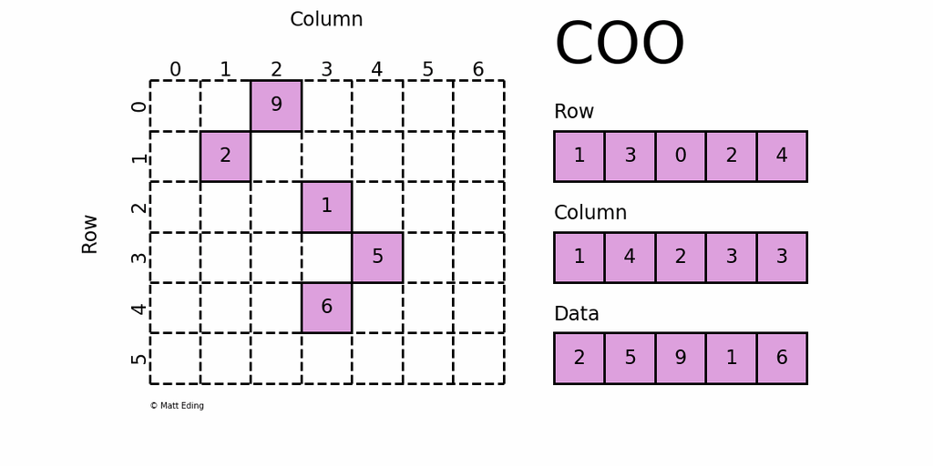

Note how only non-zero values are stored, efficiently reducing the disk storage footprint.

2. A `regions` file:

```
regions.bed
```

```bash
<chr> <start> <end>
I    1       1000
I    1001    2000
I    2001    3000
I    3001    4000
```

A more sophisticated way to do this is to parse a `pairs` file with `cooler`. `cooler` does exactly what is shown above, but then compresses and indexes the information stored in a `.cool` file.

Eventually, the `.cool` (a variant of HDF5) format is just a sophisticated file structure to store rectangular matrices. Read more [here](https://cooler.readthedocs.io/en/latest/datamodel.html).

### 5.2 Cooler

`cooler` library was written to perform several important operations:

1. `cload`: parse `.pairs` files into `.cool` files
2. `balance`: normalize Hi-C contact matrices (a.k.a “balancing”)
3. `dump`: facilitate random access of a subset of the data using genomic coordinates
4. `show`: enable visualization of Hi-C data
5. `zoomify`: generate a multi-resolution `.mcool` file from a `.cool` file

```
bash
```

```bash
cooler --help
cooler cload --help
cooler balance --help
cooler dump --help
cooler show --help
cooler zoomify --help
```

#### 5.2.1 `cooler cload`

Let’s first create a `.cool` file from a `.pairs` file. We can use any pairs file we want. In our case, since we want **filtered and pcr-free** pairs, we should use the `*valid_idx_pcrfree.pairs` file.

The generic command for `cooler cloar` is something like:

```bash
## GENERIC COMMAND: TO COMPLETE
## DO NOT RUN THIS!
cooler cload \
   pairs \
   --chrom1 ... --pos1 ... \ # chrom1 and pos1 column indices
   --chrom2 ... --pos2 ... \ # chrom2 and pos2 column indices
   <CHROMSIZES>:<BINSIZE> \ # path to chrom.sizes file followed by ":" then the desired bin size
   <PAIRS_PATH> \ # path to the input pairs file
   <COOL_PATH> # path to the output cool file
```

```
bash
```

```bash
sed 1d results/CH112.chr.tsv | cut -f1-2
```

```bash
I       230218
II      813184
III     316620
IV      1531933
V       576874
VI      270161
VII     1090940
VIII    562643
IX      439888
X       745751
XI      666816
XII     1078177
XIII    924431
XIV     784333
XV      1091291
XVI     948066
Mito    85779
```

We can execute `cooler cload` by “feeding” this text stream directly, using `<(...)` trick:

```
bash
```

```bash
mkdir results/matrix
cooler cload \
   pairs \
   --chrom1 2 --pos1 3 \
   --chrom2 4 --pos2 5 \
   <(sed 1d results/CH112.chr.tsv | cut -f1-2):1000 \
   results/pairs/CH112.valid_idx_pcrfree.pairs \
   results/matrix/CH112.cool
```

We can inspect the generated `.cool` file using `cooler`:

```
bash
```

```bash
cooler tree results/matrix/CH112.cool
cooler info results/matrix/CH112.cool
grep -v "#" results/pairs/CH112.valid_idx_pcrfree.pairs | wc -l
```

**So what does `hicstuff` generate as a contact matrix??**

If no `-binning` is set, the output of `hicstuff pipeline` is a bin-less contact matrix. Each column/row actually represents a restriction fragment, rather than a fixed-width bin. The sum of contacts (`"sum"`) is the same between the two files, but the number of bins (columns/rows) is different!

**Filtering unwanted chromosomes…**

The `<(...)` trick illustrated above allows one to easily select/remove any chromosome they want to generate a chromosome-specific `.cool` file from a `.pairs` file:

```
bash
```

```bash
# --- Only select chromosome "II"
cooler cload \
   pairs \
   --chrom1 2 --pos1 3 \
   --chrom2 4 --pos2 5 \
   <(sed 1d results/CH112.chr.tsv | cut -f1-2 | grep -P "^II\t"):1000 \
   results/pairs/CH112.valid_idx_pcrfree.pairs \
   results/matrix/CH112_chrII.cool
cooler info results/matrix/CH112_chrII.cool

# --- Filter out "Mito" chromosome
cooler cload \
   pairs \
   --chrom1 2 --pos1 3 \
   --chrom2 4 --pos2 5 \
   <(sed 1d results/CH112.chr.tsv | cut -f1-2 | grep -Pv "^Mito\t"):1000 \
   results/pairs/CH112.valid_idx_pcrfree.pairs \
   results/matrix/CH112_noMito.cool
cooler info results/matrix/CH112_noMito.cool
```

#### 5.2.2 `cooler zoomify`

One of the strength of `.cool` files is that they can be nested. In this case, one can generate a `.mcool` file, effectively containing several `.cool` files at different resolutions.

```
bash
```

```bash
cooler zoomify --help
```

We want to generate multi-resolution `.mcool` file for our Hi-C sample in order to study chromosome conformation at different scales, e.g. structural loops (~ tens of kb) to chromatin domains (~ hundreds of kb up to Mb).

At the same time, we will add normalized contact frequencies to each contact matrix. This can be done by using the `--balance` flag.

```
bash
```

```bash
cooler zoomify \
   --nproc 8 \
   --resolutions 1000,2000,4000,8000,16000 \
   --balance \
   --out results/matrix/CH112.mcool \
   results/matrix/CH112.cool
```

#### 5.2.3 Recover contacts from a `.cool` file

A `.mcool` file is actually a nested list of `.cool` files!

```
bash
```

```bash
cooler tree results/matrix/CH112.mcool
```

Append `::/resolutions/<BINSIZE>` to the end of `.mcool` file to access a specific resolution:

```
bash
```

```bash
cooler tree results/matrix/CH112.mcool::/resolutions/16000
cooler info results/matrix/CH112.mcool::/resolutions/16000
```

Raw contact counts (stored as a sparse matrix) along with the corresponding information regarding the genomic bins and the chromosomes can be recovered from a `.cool` file using `cooler dump`.

```
bash
```

```bash
cooler dump --help
cooler dump --header --table chroms results/matrix/CH112.mcool::/resolutions/16000
cooler dump --header --table bins results/matrix/CH112.mcool::/resolutions/16000 | head
cooler dump --header --table pixels --balanced results/matrix/CH112.mcool::/resolutions/16000 | head
cooler dump --header --table pixels --balanced --join results/matrix/CH112.mcool::/resolutions/16000 | head
```

One can access specific genomic locations using `--range` flag:

```
bash
```

```bash
cooler dump \
   --header \
   --table pixels \
   --balanced \
   --join \
   --range "I:48000-96000" \
   results/matrix/CH112.mcool::/resolutions/16000
```

#### 5.2.4 Imaging a contact matrix

The text format seen above is not very easy to parse, i.e. not very visually informative. Rather than dumping the `.cool` content as a text, we can use `cooler` to parse it into an image, a heatmap representing intensity of contacts between pairs of genomic loci.

```
bash
```

```bash
cooler show \
   --balanced \
   --out results/matrix/CH112_2kb-res_II-200kb-700kb.pdf \
   --dpi 500 \
   results/matrix/CH112.mcool::/resolutions/2000 \
   II:200000-700000
```

**Useful flags for cooler show**

- `--balanced` If added, will plot the **normalized** contact matrix rather than the raw counts.
- `--zmin FLOAT` The minimal value of the color scale.
- `--zmax FLOAT` The maximal value of the color scale.
- `--cmap TEXT` The colormap used to display the contact matrix (see the full list at http://matplotlib.org/examples/color/colormaps_reference.html

```
bash
```

```bash
cooler show \
   --balanced \
   --out results/matrix/CH112_2kb-res_II-200kb-700kb_-3to-1_inferno.pdf \
   --dpi 500 \
   --zmin='-3' \
   --zmax='-1' \
   --cmap="inferno" \
   results/matrix/CH112.mcool::/resolutions/2000 \
   II:200000-700000
```

## 6 Using `chromosight` to map structural features

Mapping loops made easy, by Cyril Matthey-Doret!

```
bash
```

```bash
chromosight --help
```

Generic command:

```
bash
```

```bash
## GENERIC COMMAND: TO COMPLETE
## DO NOT RUN THIS!
chromosight detect \
   --pattern loops \
   --pearson <THRESHOLD> \
   --threads <@> \
   <contact_map> \
   <prefix>
```

In our case:

```
bash
```

```bash
mkdir results/loops/
chromosight detect \
   --pattern loops \
   --pearson 0.3 \
   --threads 4 \
   results/matrix/CH112.mcool::/resolutions/2000 \
   results/loops/CH112
```

```
bash
```

```bash
tree results/loops/
head results/loops/CH112.tsv
```

## 7 Recap: from reads to loops

```
bash
```

```bash
# ------ DEFINE ENVIRONMENT VARIABLES
PREFIX=CH112
BINSIZE=1000
THREADS=12
ENZYME="DpnII,HinfI"
GENOME="genomes/S288c/S288c.fa"

# ------ Fastq -> mcool
hicstuff pipeline \
   --threads "${THREADS}" \
   --enzyme "${ENZYME}" \
   --filter \
   --duplicates \
   --prefix "${PREFIX}" \
   --binning "${BINSIZE}" \
   --plot \
   --distance-law \
   --outdir results \
   --genome "${GENOME}" \
   data/"${PREFIX}"_R1.fq.gz \
   data/"${PREFIX}"_R2.fq.gz

# ------ mcool -> loops
chromosight detect \
   --pattern loops \
   --threads "${THREADS}" \
   results/"${PREFIX}".mcool::/resolutions/"${BINSIZE}" \
   results/"${PREFIX}"
```

## 8 Going further: `cooltools`

Several advanced features are available with `cooltools`, notably:

1. Finding “dots”: i.e. finding loops in a contact map
2. Computing eigenvectors: i.e. annotating compartments in a contact map (usually @ coarse resolution)
3. Computing insulation: i.e. annotating topological domains in a contact map (usually @ finer resolution)
4. Computing pileup: a.k.a Aggregated Plot Analysis (APA)
5. Computing saddle plots

## 9 Going even further: `HiCExperiment` ecosystem in R

- [HiCExperiment](https://jserizay.com/HiCExperiment/):
  - Import and subset contact matrices (`.cool`, `.hic`, `HiC-Pro` derived…)
  - Import and subset pairs files
- [HiContacts](https://jserizay.com/HiContacts/):
  - Arithmetics: merge, divide, smoothen, balance, autocorrelate, …
  - Analysis: P(s), virtual 4C, scalograms, cis/trans interactions
  - Mapping: chromatin loops (via `chromosight`), topological domains, compartments
  - Visualizing: contact maps, features, aggregated maps, saddle plots
- [HiCool](https://jserizay.com/HiCool/):
  - Runs `hicstuff`+`cooler` embarked in R
  - Generates multi-resolution, balanced `.mcool` files from read pairs
  - Computes automated reports
- [fourDNData](https://jserizay.com/HiCool/):
  - Gateway to the 4DN consortium data portal

## 10 Extra: Integrating HiC with other genome-wide modalities

```
bash
```

```bash
mamba install -c bioconda \
   bioconductor-rtracklayer \
   bioconductor-plyranges \
   r-ggplot2 \
   r-tidyr
```

```
R
```

```r
library(ggplot2)
library(rtracklayer)
library(plyranges)

# - Import gene annotations as GenomicRanges
genes <- import('genomes/S288c/S288c.gtf') |>
   filter(type == 'gene')

# - Import tracks as Run-length vectors
scc1 <- import('tracks/CH224.CPM.bw', as = 'Rle')
rnaseq_fwd <- import('tracks/SRR2045244.fwd.CPM.bw', as = 'Rle')
rnaseq_rev <- import('tracks/SRR2045244.rev.CPM.bw', as = 'Rle')

# - Define locus of interest
locus <- GRanges("II:300000-350000")
bins <- tile(locus, width = 10)[[1]]

# - Average tracks over bins
df <- data.frame(
   pos = start(bins),
   scc1 = mean(scc1[bins]),
   rnaseq_fwd = mean(rnaseq_fwd[bins]),
   rnaseq_rev = -mean(rnaseq_rev[bins])
) |>
   tidyr::pivot_longer(-pos, names_to = 'track', values_to = 'score') |>
   dplyr::mutate(track = factor(track, c('scc1', 'rnaseq_fwd', 'rnaseq_rev')))

# - Plot tracks
p <- ggplot(df, aes(x = pos, y = score, fill = track)) +
   geom_area(position = 'identity', alpha = 0.5) +
   scale_x_continuous(expand = c(0, 0)) +
   theme_bw() +
   theme(legend.position = 'bottom')
ggsave('results/plots/tracks.pdf', width = 10, height = 4)

# - Plot faceted tracks
p <- ggplot(df, aes(x = pos, y = score, fill = track)) +
   geom_area(position = 'identity') +
   scale_x_continuous(expand = c(0, 0)) +
   theme_bw() +
   theme(legend.position = 'bottom') +
   facet_grid(track~., scales = 'free')
ggsave('results/plots/tracks_facets.pdf', width = 10, height = 7)
```